# R Notebook

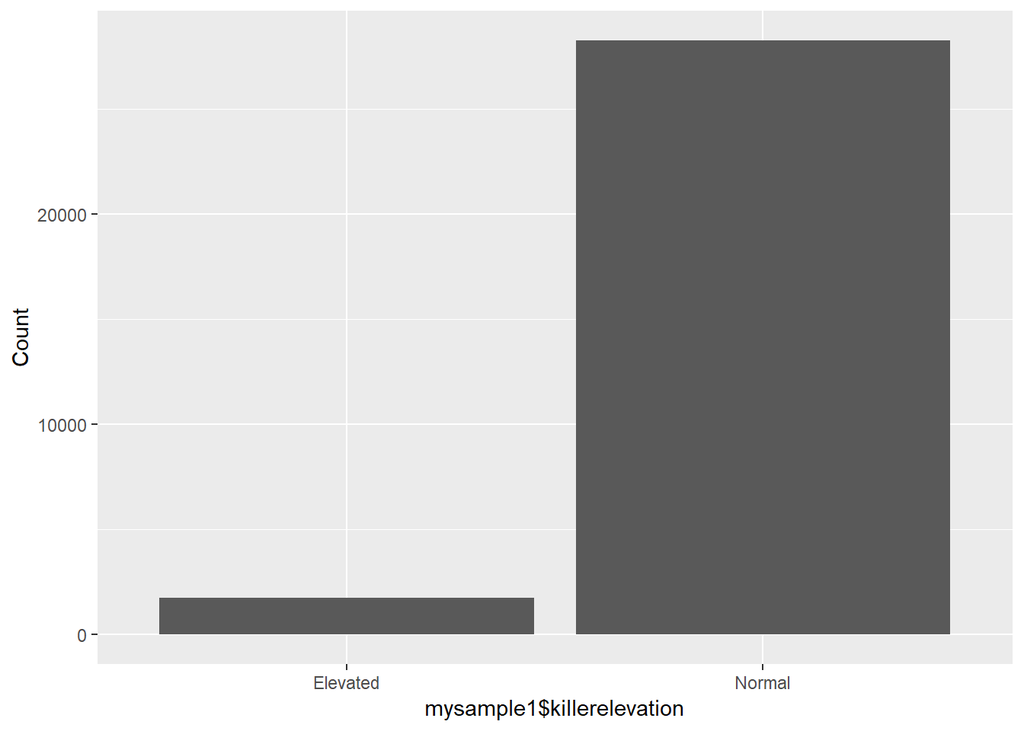

```r
histo_charts(mysample1, mysample1$killerelevation)
```

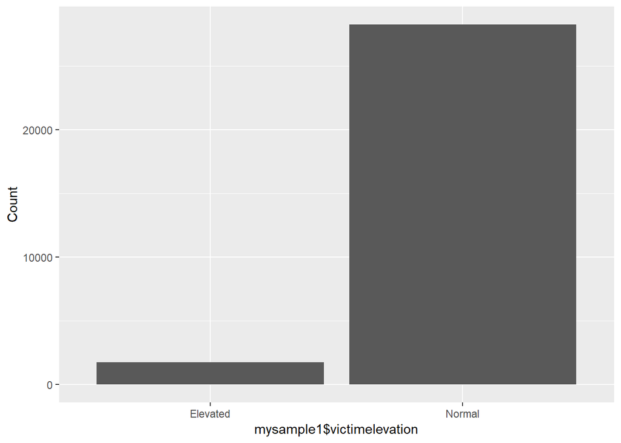

```r
histo_charts(mysample1, mysample1$victimelevation)
```

Histograms for sample 2

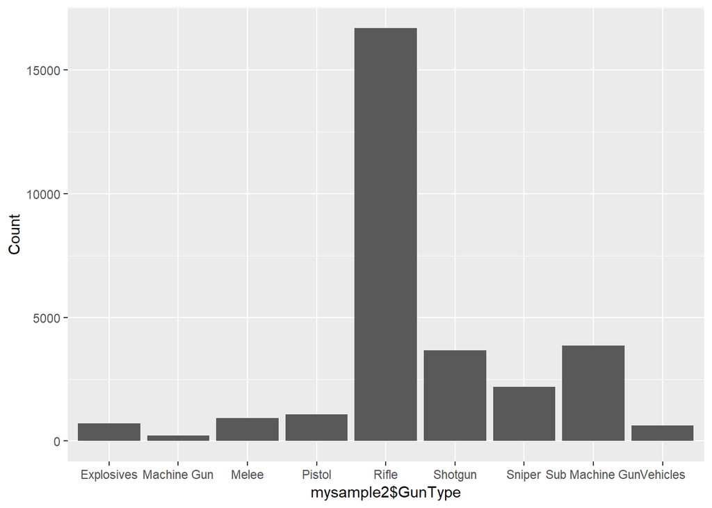

```r
histo_charts(mysample2, mysample2$GunType)
```

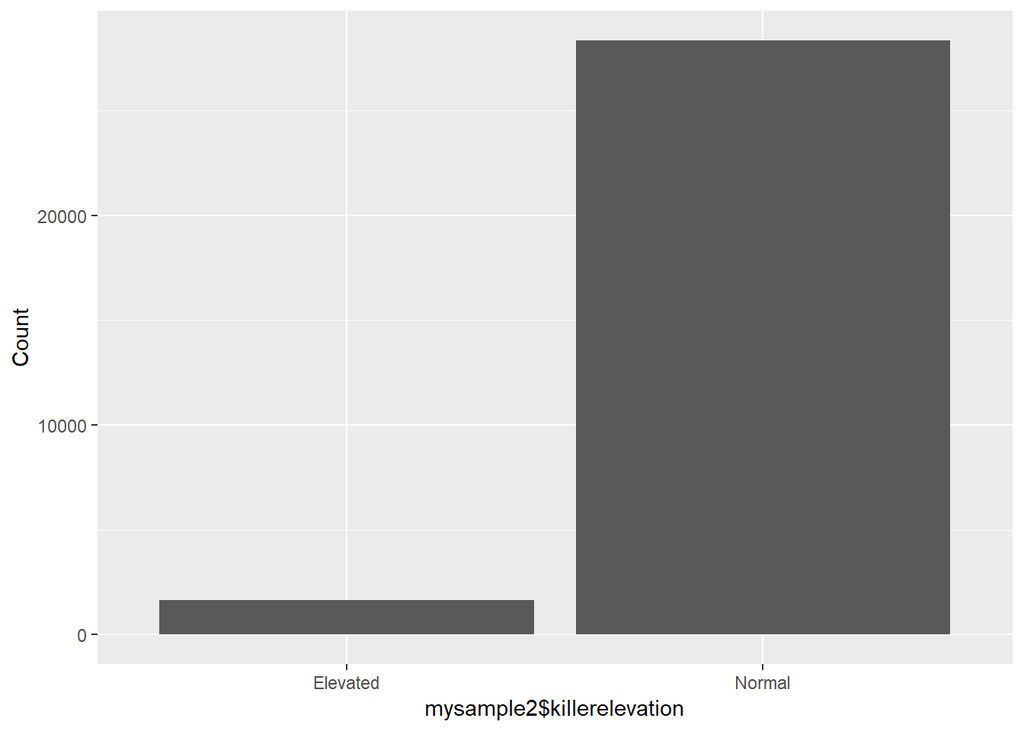

```r
histo_charts(mysample2, mysample2$killerelevation)
```

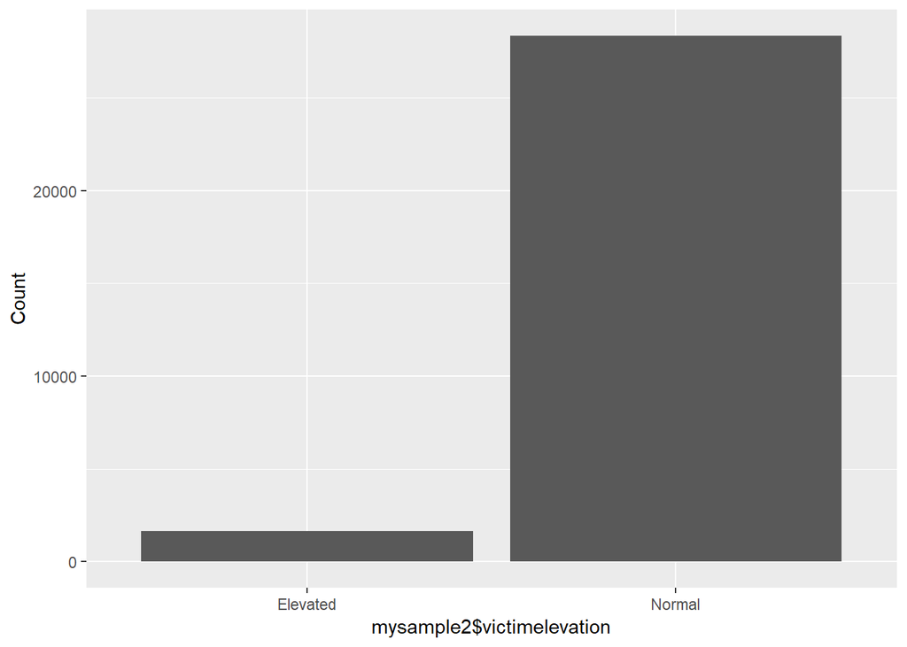

```r
histo_charts(mysample2, mysample2$victimelevation)
```

Histogram for sample 3

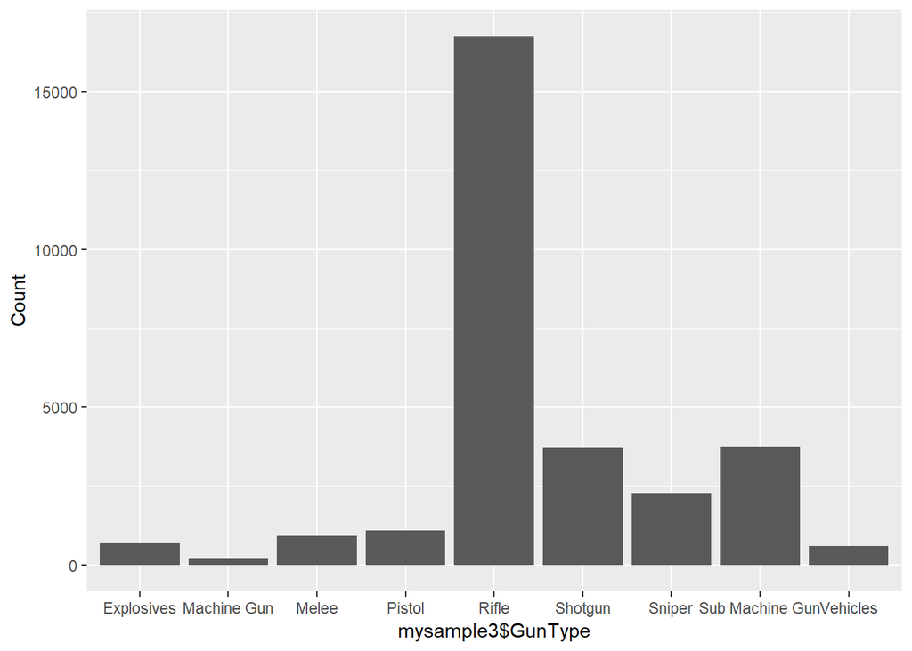

```r
histo_charts(mysample3, mysample3$GunType)
```

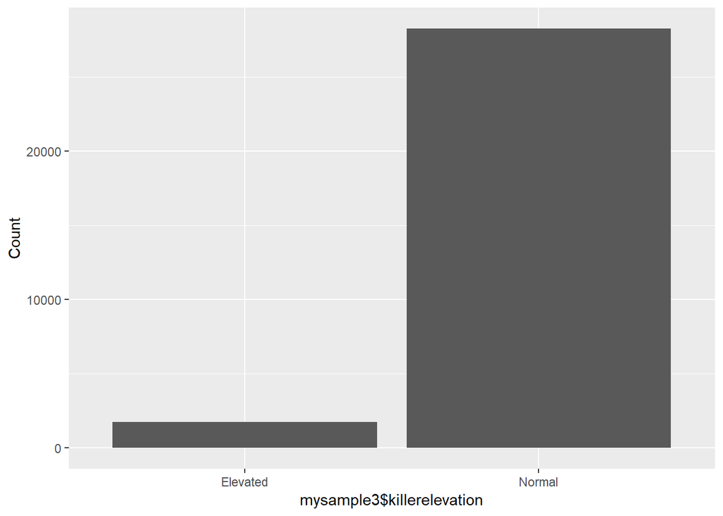

```r
histo_charts(mysample3, mysample3$killerelevation)
```

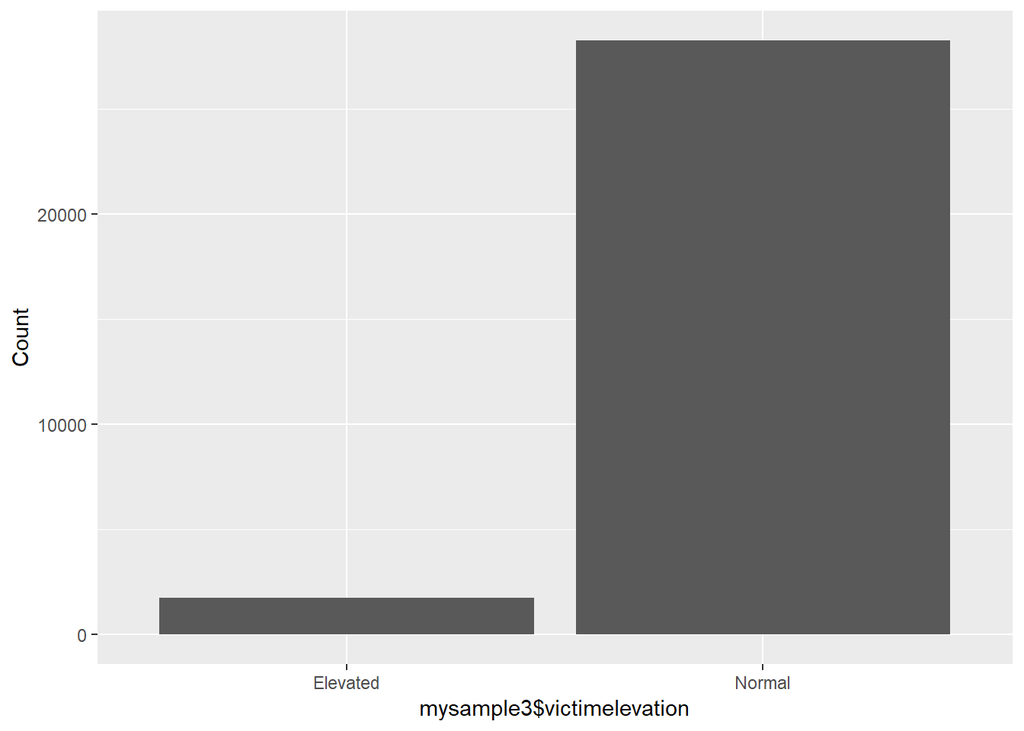

```r
histo_charts(mysample3, mysample3$victimelevation)
```

Creating function for scatterplot diagram

```r
scatterplot_func <- function(dataa, xaxis, yaxis)
{
  ggplot(dataa, aes(x=xaxis, y=yaxis)) + geom_point()
  ggplot(dataa, aes(x=xaxis, y=yaxis)) +
  geom_point()+
  geom_smooth(method=lm) +
  labs( y = deparse((substitute(yaxis))), x =deparse((substitute(xaxis))))
}
```

Creating scatterplots

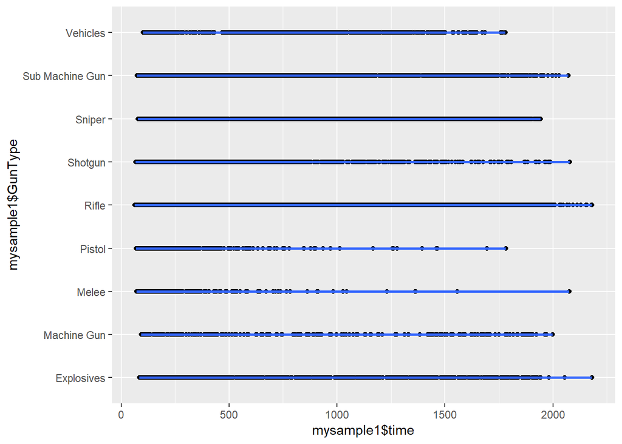

```r
scatterplot_func(mysample1, mysample1$time, mysample1$GunType)
```

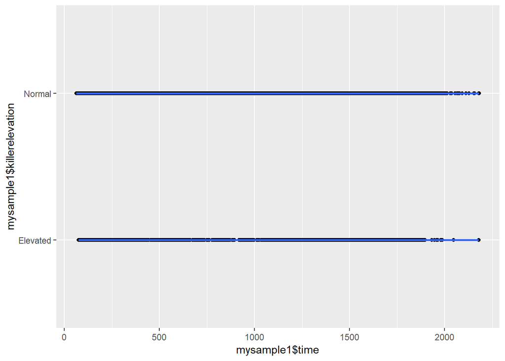

```r
scatterplot_func(mysample1, mysample1$time, mysample1$killerelevation)
```

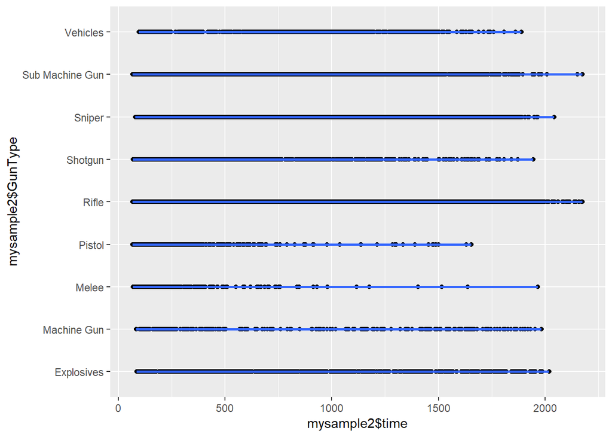

```r
scatterplot_func(mysample2, mysample2$time, mysample2$GunType)
```

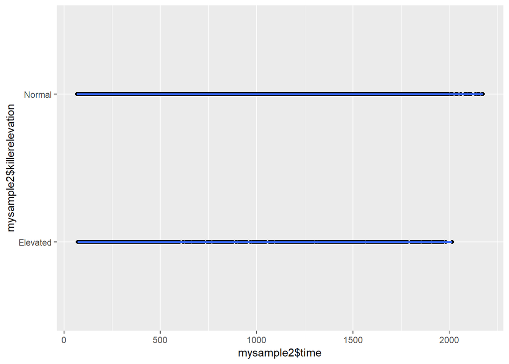

```r
scatterplot_func(mysample2, mysample2$time, mysample2$killerelevation)
```

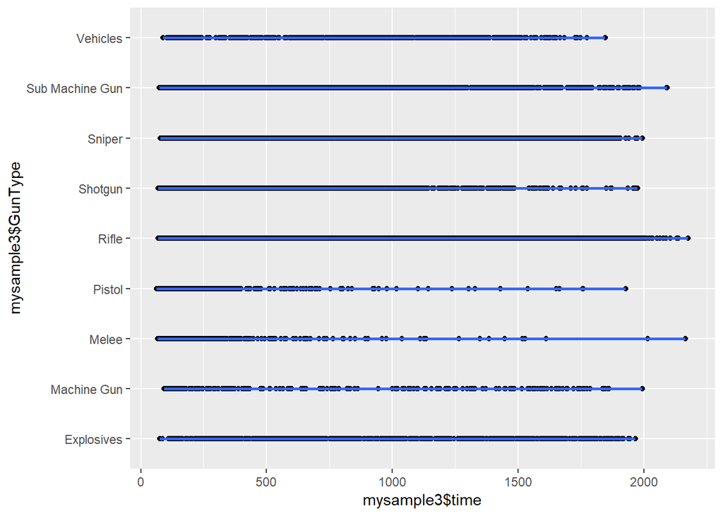

```r
scatterplot_func(mysample3, mysample3$time, mysample3$GunType)
```

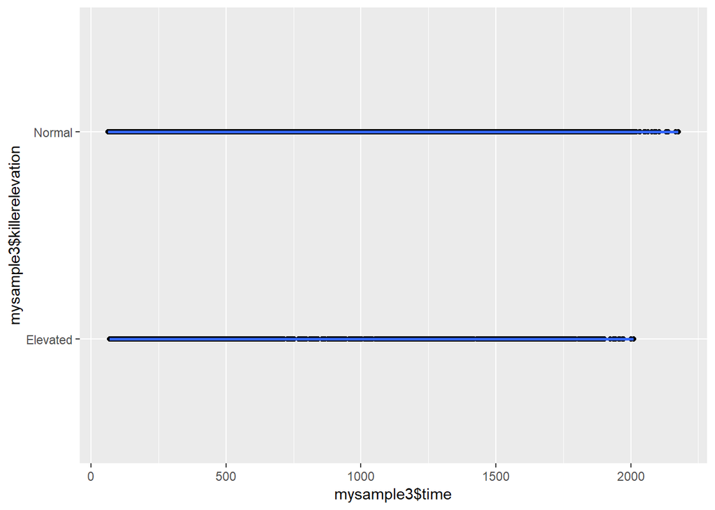

```r
scatterplot_func(mysample3, mysample3$time, mysample3$killerelevation)
```

Creating one hot encoding for gun type and elevation

```r
temp<- mysample1
dmy <- dummyVars("~GunType", data = temp)
onehots <- data.frame(predict(dmy, newdata = temp))
temp <- cbind(temp, onehots)

dmy1 <- dummyVars("~killerelevation", data = temp)
onehots <- data.frame(predict(dmy1, newdata = temp))
temp <- cbind(temp, onehots)

dmy2 <- dummyVars("~victimelevation", data = temp)
onehots <- data.frame(predict(dmy2, newdata = temp))
temp <- cbind(temp, onehots)



head(temp)
```

|  | killer_position_x | killer_position_y | victim_position_x | victim_position_y | killed_by | time | GunType | killerelevation | victimelevation | killdistance | GunType.Explosives | GunType.Machine.Gun | GunType.Melee | GunType.Pistol | GunType.Rifle | GunType.Shotgun | GunType.Sniper | GunType.Sub.Machine.Gun | GunType.Vehicles | killerelevation.Elevated | killerelevation.Normal | victimelevation.Elevated | victimelevation.Normal |
| --- | --- | --- | --- | --- | --- | --- | --- | --- | --- | --- | --- | --- | --- | --- | --- | --- | --- | --- | --- | --- | --- | --- | --- |
| 17983082 | 545715.9 | 448817.5 | 544267.2 | 448689.6 | R1895 | 178 | Pistol | Normal | Normal | 1454.3349 | 0 | 0 | 0 | 1 | 0 | 0 | 0 | 0 | 0 | 0 | 1 | 0 | 1 |
| 35651476 | 197831.5 | 275609.5 | 200813.5 | 274437.3 | M416 | 313 | Rifle | Normal | Normal | 3204.1187 | 0 | 0 | 0 | 0 | 1 | 0 | 0 | 0 | 0 | 0 | 1 | 0 | 1 |
| 35416314 | 691412.6 | 352455.4 | 691865.0 | 352029.3 | Hit by Car | 683 | Vehicles | Normal | Normal | 621.4716 | 0 | 0 | 0 | 0 | 0 | 0 | 0 | 0 | 1 | 0 | 1 | 0 | 1 |
| 37983244 | 505679.8 | 295653.8 | 493361.7 | 289160.3 | SKS | 832 | Sniper | Normal | Normal | 13924.8386 | 0 | 0 | 0 | 0 | 0 | 0 | 1 | 0 | 0 | 0 | 1 | 0 | 1 |
| 31394839 | 501322.8 | 230117.1 | 495197.9 | 230023.2 | Grenade | 1510 | Explosives | Normal | Normal | 6125.6197 | 1 | 0 | 0 | 0 | 0 | 0 | 0 | 0 | 0 | 0 | 1 | 0 | 1 |
| 12169247 | 467174.8 | 472545.6 | 465387.9 | 472747.9 | SCAR-L | 633 | Rifle | Normal | Normal | 1798.3150 | 0 | 0 | 0 | 0 | 1 | 0 | 0 | 0 | 0 | 0 | 1 | 0 | 1 |

```r
temp <- temp[,-5]
temp <- temp[,-6]
temp <- temp[,-6]
temp <- temp[,-6]

corval <- cor(temp) #creating a correalation matrix
round(corval,3)
```

```
##                          killer_position_x killer_position_y
## killer_position_x                    1.000             0.104
## killer_position_y                    0.104             1.000
## victim_position_x                    0.999             0.104
## victim_position_y                    0.104             0.999
## time                                -0.060            -0.068
## killdistance                        -0.024            -0.009
## GunType.Explosives                   0.007            -0.014
## GunType.Machine.Gun                 -0.008             0.005
## GunType.Melee                        0.003            -0.001
## GunType.Pistol                       0.013            -0.014
## GunType.Rifle                       -0.012            -0.008
## GunType.Shotgun                      0.017             0.024
## GunType.Sniper                      -0.006             0.022
## GunType.Sub.Machine.Gun             -0.001            -0.018
## GunType.Vehicles                    -0.005             0.007
## killerelevation.Elevated             0.033             0.346
## killerelevation.Normal              -0.033            -0.346
## victimelevation.Elevated             0.035             0.346
## victimelevation.Normal              -0.035            -0.346
##                          victim_position_x victim_position_y   time
## killer_position_x                    0.999             0.104 -0.060
## killer_position_y                    0.104             0.999 -0.068
## victim_position_x                    1.000             0.104 -0.060
## victim_position_y                    0.104             1.000 -0.068
## time                                -0.060            -0.068  1.000
## killdistance                        -0.024            -0.010  0.341
## GunType.Explosives                   0.007            -0.014  0.054
## GunType.Machine.Gun                 -0.008             0.005  0.019
## GunType.Melee                        0.003            -0.001 -0.170
## GunType.Pistol                       0.013            -0.014 -0.180
## GunType.Rifle                       -0.012            -0.009  0.285
## GunType.Shotgun                      0.017             0.024 -0.272
## GunType.Sniper                      -0.006             0.023  0.180
## GunType.Sub.Machine.Gun             -0.001            -0.018 -0.161
## GunType.Vehicles                    -0.005             0.007  0.033
## killerelevation.Elevated             0.033             0.345  0.014
## killerelevation.Normal              -0.033            -0.345 -0.014
## victimelevation.Elevated             0.035             0.346  0.012
## victimelevation.Normal              -0.035            -0.346 -0.012
```

[output cut: 105 more lines]

```
## time                                        0.012                 -0.012
## killdistance                                0.006                 -0.006
## GunType.Explosives                         -0.005                  0.005
## GunType.Machine.Gun                         0.005                 -0.005
## GunType.Melee                               0.002                 -0.002
## GunType.Pistol                              0.006                 -0.006
## GunType.Rifle                               0.003                 -0.003
## GunType.Shotgun                            -0.002                  0.002
## GunType.Sniper                              0.012                 -0.012
## GunType.Sub.Machine.Gun                    -0.014                  0.014
## GunType.Vehicles                           -0.005                  0.005
## killerelevation.Elevated                    0.948                 -0.948
## killerelevation.Normal                     -0.948                  0.948
## victimelevation.Elevated                    1.000                 -1.000
## victimelevation.Normal                     -1.000                  1.000
```

Splitting data into test set and training set

```r
set.seed(250)
index1 <- createDataPartition(mysample1$GunType, p=0.75, list = FALSE)
mysample1_train<-mysample1[index1,]
mysample1_test<-mysample1[-index1,]

set.seed(250)
index2 <- createDataPartition(mysample2$GunType, p=0.75, list = FALSE)
mysample2_train<-mysample2[index2,]
mysample2_test<-mysample2[-index2,]

set.seed(250)
index3 <- createDataPartition(mysample3$GunType, p=0.75, list = FALSE)
mysample3_train<-mysample3[index3,]
mysample3_test<-mysample3[-index3,]

set.seed(250)
sindex1 <- createDataPartition(smysample1$GunType, p=0.75, list = FALSE)
smysample1_train<-mysample1[sindex1,]
smysample1_test<-mysample1[-sindex1,]
```

kNN on non scaled data

```r
set.seed(400)
training_control <- trainControl(method = "repeatedcv", number=10, repeats = 3)
#knn <- readRDS("./knn_salesnormalized_model.rds")
knn1 <- train(GunType ~. - killed_by, data = mysample1_train, method = "knn", metric = "Kappa",  trControl = training_control) #,

knn_pred1 <- predict(knn1, newdata = mysample1_test)

confusionMatrix(knn_pred1,mysample1_test$GunType)
```

```
## Confusion Matrix and Statistics
##
##                  Reference
## Prediction        Explosives Machine Gun Melee Pistol Rifle Shotgun Sniper
##   Explosives               0           0     2      0    12       5      2
##   Machine Gun              0           0     0      0     4       1      1
##   Melee                    2           0    16      9    50      20      6
##   Pistol                   2           1    14     14    63      39      3
##   Rifle                  139          46   123    151  3212     493    468
##   Shotgun                 18           8    45     46   396     194     22
##   Sniper                   4           1     1      4   103       4     50
##   Sub Machine Gun         15           3    20     46   337     148     15
##   Vehicles                 1           0     4      1    18       1      3
##                  Reference
## Prediction        Sub Machine Gun Vehicles
##   Explosives                    4        0
##   Machine Gun                   1        0
##   Melee                        14        4
##   Pistol                       26        4
##   Rifle                       591      131
##   Shotgun                     171        4
##   Sniper                        7        4
##   Sub Machine Gun             114        7
##   Vehicles                      3        7
##
## Overall Statistics
##
##                Accuracy : 0.4811
##                  95% CI : (0.4697, 0.4924)
##     No Information Rate : 0.5595
##     P-Value [Acc > NIR] : 1
##
##                   Kappa : 0.0912
##  Mcnemar's Test P-Value : NA
##
## Statistics by Class:
##
##                      Class: Explosives Class: Machine Gun Class: Melee
## Sensitivity                   0.000000          0.0000000     0.071111
## Specificity                   0.996583          0.9990590     0.985563
```

[output cut: 9 more lines]

```
## Pos Pred Value            0.084337       0.5999        0.21460
## Neg Pred Value            0.964948       0.5415        0.89217
## Prevalence                0.036143       0.5595        0.12070
## Detection Rate            0.001867       0.4284        0.02587
## Detection Prevalence      0.022139       0.7141        0.12057
## Balanced Accuracy         0.515314       0.5586        0.55334
##                      Class: Sniper Class: Sub Machine Gun Class: Vehicles
## Sensitivity               0.087719                0.12245       0.0434783
## Specificity               0.981524                0.91000       0.9957748
## Pos Pred Value            0.280899                0.16170       0.1842105
## Neg Pred Value            0.928962                0.87973       0.9793566
## Prevalence                0.076020                0.12417       0.0214724
## Detection Rate            0.006668                0.01520       0.0009336
## Detection Prevalence      0.023740                0.09403       0.0050680
## Balanced Accuracy         0.534622                0.51623       0.5196266
```

```r
saveRDS(knn, "./knn1.rds")

set.seed(777)

#knn <- readRDS("./knn_salesnormalized_model.rds")
knn2 <- train(GunType ~.  - killed_by, data = mysample2_train, method = "knn", metric = "Kappa",  trControl = training_control) #,

knn_pred2 <- predict(knn2, newdata = mysample2_test)

confusionMatrix(knn_pred2,mysample2_test$GunType)
```

```
## Confusion Matrix and Statistics
##
##                  Reference
## Prediction        Explosives Machine Gun Melee Pistol Rifle Shotgun Sniper
##   Explosives               0           0     2      2    16       1      1
##   Machine Gun              0           0     0      1     2       1      0
##   Melee                    2           0    15      8    33      26      4
##   Pistol                   3           1    11     11    44      37      7
##   Rifle                  132          44   134    146  3251     513    466
##   Shotgun                 19          10    46     63   366     215     15
##   Sniper                   1           2     3      0    96       4     38
##   Sub Machine Gun         19           1    21     40   344     119     17
##   Vehicles                 2           0     0      0    20       0      1
##                  Reference
## Prediction        Sub Machine Gun Vehicles
##   Explosives                    4        0
##   Machine Gun                   1        0
##   Melee                         8        0
##   Pistol                       20        2
##   Rifle                       619      134
##   Shotgun                     195        4
##   Sniper                       13        4
##   Sub Machine Gun             103        8
##   Vehicles                      4        3
##
## Overall Statistics
##
##                Accuracy : 0.4849
##                  95% CI : (0.4736, 0.4963)
##     No Information Rate : 0.5564
##     P-Value [Acc > NIR] : 1
##
##                   Kappa : 0.0913
##  Mcnemar's Test P-Value : NA
##
## Statistics by Class:
##
##                      Class: Explosives Class: Machine Gun Class: Melee
## Sensitivity                   0.000000          0.0000000     0.064655
## Specificity                   0.996448          0.9993280     0.988852
```

[output cut: 9 more lines]

```
## Pos Pred Value            0.080882       0.5977        0.23044
## Neg Pred Value            0.964684       0.5527        0.89322
## Prevalence                0.036143       0.5564        0.12217
## Detection Rate            0.001467       0.4336        0.02867
## Detection Prevalence      0.018138       0.7254        0.12443
## Balanced Accuracy         0.511647       0.5607        0.56282
##                      Class: Sniper Class: Sub Machine Gun Class: Vehicles
## Sensitivity               0.069217                0.10651       0.0193548
## Specificity               0.982300                0.91288       0.9963230
## Pos Pred Value            0.236025                0.15327       0.1000000
## Neg Pred Value            0.930353                0.87343       0.9796465
## Prevalence                0.073220                0.12897       0.0206722
## Detection Rate            0.005068                0.01374       0.0004001
## Detection Prevalence      0.021472                0.08962       0.0040011
## Balanced Accuracy         0.525758                0.50970       0.5078389
```

```r
saveRDS(knn, "./knn2.rds")

set.seed(111)

#knn <- readRDS("./knn_salesnormalized_model.rds")
knn3 <- train(GunType ~.  - killed_by, data = mysample3_train, method = "knn", metric = "Kappa",  trControl = training_control) #,

knn_pred3 <- predict(knn3, newdata = mysample3_test)

confusionMatrix(knn_pred3,mysample3_test$GunType)
```

```
## Confusion Matrix and Statistics
##
##                  Reference
## Prediction        Explosives Machine Gun Melee Pistol Rifle Shotgun Sniper
##   Explosives               2           0     0      3    17       5      1
##   Machine Gun              0           0     0      0     1       0      0
##   Melee                    3           0    18      7    58      23      4
##   Pistol                   3           1    11     12    69      25      2
##   Rifle                  135          42   119    143  3240     512    466
##   Shotgun                 16           4    58     60   388     225     26
##   Sniper                   2           1     1      0    89       5     44
##   Sub Machine Gun         10           4    21     48   306     131     20
##   Vehicles                 1           0     2      0    19       2      0
##                  Reference
## Prediction        Sub Machine Gun Vehicles
##   Explosives                    4        1
##   Machine Gun                   0        0
##   Melee                        21        1
##   Pistol                       25        0
##   Rifle                       582      127
##   Shotgun                     165        9
##   Sniper                        4        3
##   Sub Machine Gun             134       10
##   Vehicles                      2        3
##
## Overall Statistics
##
##                Accuracy : 0.4907
##                  95% CI : (0.4793, 0.502)
##     No Information Rate : 0.5586
##     P-Value [Acc > NIR] : 1
##
##                   Kappa : 0.1066
##  Mcnemar's Test P-Value : NA
##
## Statistics by Class:
##
##                      Class: Explosives Class: Machine Gun Class: Melee
## Sensitivity                  0.0116279          0.0000000     0.078261
## Specificity                  0.9957673          0.9998657     0.983898
```

[output cut: 9 more lines]

```
## Pos Pred Value            0.081081       0.6038        0.23659
## Neg Pred Value            0.964480       0.5554        0.89259
## Prevalence                0.036419       0.5586        0.12380
## Detection Rate            0.001601       0.4322        0.03002
## Detection Prevalence      0.019744       0.7158        0.12687
## Balanced Accuracy         0.512564       0.5657        0.56596
##                      Class: Sniper Class: Sub Machine Gun Class: Vehicles
## Sensitivity                0.07815                0.14301       0.0194805
## Specificity                0.98486                0.91615       0.9964587
## Pos Pred Value             0.29530                0.19591       0.1034483
## Neg Pred Value             0.92936                0.88212       0.9797777
## Prevalence                 0.07511                0.12500       0.0205443
## Detection Rate             0.00587                0.01788       0.0004002
## Detection Prevalence       0.01988                0.09125       0.0038687
## Balanced Accuracy          0.53150                0.52958       0.5079696
```

```r
saveRDS(knn, "./knn3.rds")
```

kNN on scaled data

```r
straining_control <- trainControl(method = "repeatedcv", number=10, repeats = 3)
#knn <- readRDS("./knn_salesnormalized_model.rds")
sknn1 <- train(GunType ~., data = smysample1_train, method = "knn", metric = "Kappa",  trControl = straining_control) #,

sknn_pred1 <- predict(sknn1, newdata = smysample1_test)

confusionMatrix(sknn_pred1,smysample1_test$GunType)
```

```
## Confusion Matrix and Statistics
##
##                  Reference
## Prediction        Explosives Machine Gun Melee Pistol Rifle Shotgun Sniper
##   Explosives               1           0     3      0    17       5      3
##   Machine Gun              0           0     1      0     6       1      0
##   Melee                    4           0    17      6    51      21      6
##   Pistol                   0           3    14     10    67      30      1
##   Rifle                  139          45   121    151  3213     491    462
##   Shotgun                 18           6    39     50   395     207     25
##   Sniper                   2           1     2      3   108       4     54
##   Sub Machine Gun         15           4    24     50   319     143     16
##   Vehicles                 2           0     4      1    19       3      3
##                  Reference
## Prediction        Sub Machine Gun Vehicles
##   Explosives                    4        0
##   Machine Gun                   1        0
##   Melee                        15        5
##   Pistol                       23        3
##   Rifle                       600      130
##   Shotgun                     169        5
##   Sniper                        7        5
##   Sub Machine Gun             108        5
##   Vehicles                      4        8
##
## Overall Statistics
##
##                Accuracy : 0.4825
##                  95% CI : (0.4712, 0.4939)
##     No Information Rate : 0.5595
##     P-Value [Acc > NIR] : 1
##
##                   Kappa : 0.0941
##  Mcnemar's Test P-Value : NA
##
## Statistics by Class:
##
##                      Class: Explosives Class: Machine Gun Class: Melee
## Sensitivity                  0.0055249           0.000000     0.075556
## Specificity                  0.9956266           0.998790     0.985151
```

[output cut: 9 more lines]

```
## Pos Pred Value            0.066225       0.6003        0.22648
## Neg Pred Value            0.964475       0.5424        0.89399
## Prevalence                0.036143       0.5595        0.12070
## Detection Rate            0.001334       0.4285        0.02761
## Detection Prevalence      0.020139       0.7138        0.12190
## Balanced Accuracy         0.508695       0.5592        0.56075
##                      Class: Sniper Class: Sub Machine Gun Class: Vehicles
## Sensitivity               0.094737                0.11600        0.049689
## Specificity               0.980947                0.91229        0.995093
## Pos Pred Value            0.290323                0.15789        0.181818
## Neg Pred Value            0.929431                0.87922        0.979474
## Prevalence                0.076020                0.12417        0.021472
## Detection Rate            0.007202                0.01440        0.001067
## Detection Prevalence      0.024807                0.09122        0.005868
## Balanced Accuracy         0.537842                0.51415        0.522391
```

Rule learning on non scaled data

```r
set.seed(333)
JRips1 <- JRip(GunType ~ . - killed_by, data = mysample1_train)
predict_Jrips1<-predict(JRips1,mysample1_test)
summary(predict_Jrips1)
```

```
##      Explosives     Machine Gun           Melee          Pistol
##              74               0             242               0
##           Rifle         Shotgun          Sniper Sub Machine Gun
##            7017              53              77               0
##        Vehicles
##              35
```

```r
confusionMatrix(predict_Jrips1,mysample1_test$GunType)
```

```
## Confusion Matrix and Statistics
##
##                  Reference
## Prediction        Explosives Machine Gun Melee Pistol Rifle Shotgun Sniper
##   Explosives              51           0     0      0     0       0      0
##   Machine Gun              0           0     0      0     0       0      0
##   Melee                    0           1   148     17    31      27      2
##   Pistol                   0           0     0      0     0       0      0
##   Rifle                  114          57    74    251  4109     860    532
##   Shotgun                  0           1     3      3    12      18      2
##   Sniper                   0           0     0      0    43       0     34
##   Sub Machine Gun          0           0     0      0     0       0      0
##   Vehicles                16           0     0      0     0       0      0
##                  Reference
## Prediction        Sub Machine Gun Vehicles
##   Explosives                    0       23
##   Machine Gun                   0        0
##   Melee                        14        2
##   Pistol                        0        0
##   Rifle                       903      117
##   Shotgun                      14        0
##   Sniper                        0        0
##   Sub Machine Gun               0        0
##   Vehicles                      0       19
##
## Overall Statistics
##
##                Accuracy : 0.584
##                  95% CI : (0.5728, 0.5952)
##     No Information Rate : 0.5595
##     P-Value [Acc > NIR] : 9.453e-06
##
##                   Kappa : 0.1214
##  Mcnemar's Test P-Value : NA
##
## Statistics by Class:
##
##                      Class: Explosives Class: Machine Gun Class: Melee
## Sensitivity                   0.281768           0.000000      0.65778
## Specificity                   0.996857           1.000000      0.98708
```

[output cut: 9 more lines]

```
## Pos Pred Value                 NaN       0.5856       0.339623
## Neg Pred Value             0.96386       0.8212       0.880860
## Prevalence                 0.03614       0.5595       0.120699
## Detection Rate             0.00000       0.5480       0.002401
## Detection Prevalence       0.00000       0.9358       0.007069
## Balanced Accuracy          0.50000       0.5495       0.507290
##                      Class: Sniper Class: Sub Machine Gun Class: Vehicles
## Sensitivity               0.059649                 0.0000        0.118012
## Specificity               0.993793                 1.0000        0.997819
## Pos Pred Value            0.441558                    NaN        0.542857
## Neg Pred Value            0.927773                 0.8758        0.980973
## Prevalence                0.076020                 0.1242        0.021472
## Detection Rate            0.004535                 0.0000        0.002534
## Detection Prevalence      0.010269                 0.0000        0.004668
## Balanced Accuracy         0.526721                 0.5000        0.557916
```

```r
saveRDS(JRips1, "./Jrips1.rds")


set.seed(222)
JRips2 <- JRip(GunType ~ . - killed_by, data = mysample2_train)
predict_Jrips2<-predict(JRips2,mysample2_test)
summary(predict_Jrips2)
```

```
##      Explosives     Machine Gun           Melee          Pistol
##              91               0             212               9
##           Rifle         Shotgun          Sniper Sub Machine Gun
##            7145               0              25               0
##        Vehicles
##              16
```

```r
confusionMatrix(predict_Jrips2,mysample2_test$GunType)
```

```
## Confusion Matrix and Statistics
##
##                  Reference
## Prediction        Explosives Machine Gun Melee Pistol Rifle Shotgun Sniper
##   Explosives              58           0     0      0     1       0      0
##   Machine Gun              0           0     0      0     0       0      0
##   Melee                    0           2   141     12    13      22      4
##   Pistol                   0           0     1      3     1       2      0
##   Rifle                  110          56    90    256  4142     892    535
##   Shotgun                  0           0     0      0     0       0      0
##   Sniper                   0           0     0      0    15       0     10
##   Sub Machine Gun          0           0     0      0     0       0      0
##   Vehicles                10           0     0      0     0       0      0
##                  Reference
## Prediction        Sub Machine Gun Vehicles
##   Explosives                    0       32
##   Machine Gun                   0        0
##   Melee                        17        1
##   Pistol                        0        2
##   Rifle                       950      114
##   Shotgun                       0        0
##   Sniper                        0        0
##   Sub Machine Gun               0        0
##   Vehicles                      0        6
##
## Overall Statistics
##
##                Accuracy : 0.5815
##                  95% CI : (0.5702, 0.5927)
##     No Information Rate : 0.5564
##     P-Value [Acc > NIR] : 6.289e-06
##
##                   Kappa : 0.1063
##  Mcnemar's Test P-Value : NA
##
## Statistics by Class:
##
##                      Class: Explosives Class: Machine Gun Class: Melee
## Sensitivity                   0.325843           0.000000      0.60776
## Specificity                   0.995492           1.000000      0.99023
```

[output cut: 9 more lines]

```
## Pos Pred Value           0.3333333      0.57971            NaN
## Neg Pred Value           0.9642142      0.91501         0.8778
## Prevalence               0.0361430      0.55642         0.1222
## Detection Rate           0.0004001      0.55241         0.0000
## Detection Prevalence     0.0012003      0.95292         0.0000
## Balanced Accuracy        0.5051199      0.54496         0.5000
##                      Class: Sniper Class: Sub Machine Gun Class: Vehicles
## Sensitivity               0.018215                  0.000       0.0387097
## Specificity               0.997841                  1.000       0.9986382
## Pos Pred Value            0.400000                    NaN       0.3750000
## Neg Pred Value            0.927874                  0.871       0.9800855
## Prevalence                0.073220                  0.129       0.0206722
## Detection Rate            0.001334                  0.000       0.0008002
## Detection Prevalence      0.003334                  0.000       0.0021339
## Balanced Accuracy         0.508028                  0.500       0.5186739
```

```r
saveRDS(JRips2, "./Jrips2.rds")


set.seed(444)
JRips3 <- JRip(GunType ~ . - killed_by, data = mysample3_train)
predict_Jrips3<-predict(JRips3,mysample3_test)
summary(predict_Jrips3)
```

```
##      Explosives     Machine Gun           Melee          Pistol
##              59               0             224               0
##           Rifle         Shotgun          Sniper Sub Machine Gun
##            7133               0              33               0
##        Vehicles
##              47
```

```r
confusionMatrix(predict_Jrips3,mysample3_test$GunType)
```

```
## Confusion Matrix and Statistics
##
##                  Reference
## Prediction        Explosives Machine Gun Melee Pistol Rifle Shotgun Sniper
##   Explosives              45           0     0      0     0       0      0
##   Machine Gun              0           0     0      0     0       0      0
##   Melee                    2           0   146      9    25      19      5
##   Pistol                   0           0     0      0     0       0      0
##   Rifle                  103          52    83    264  4137     909    550
##   Shotgun                  0           0     0      0     0       0      0
##   Sniper                   0           0     0      0    25       0      8
##   Sub Machine Gun          0           0     0      0     0       0      0
##   Vehicles                22           0     1      0     0       0      0
##                  Reference
## Prediction        Sub Machine Gun Vehicles
##   Explosives                    0       14
##   Machine Gun                   0        0
##   Melee                        16        2
##   Pistol                        0        0
##   Rifle                       919      116
##   Shotgun                       0        0
##   Sniper                        0        0
##   Sub Machine Gun               0        0
##   Vehicles                      2       22
##
## Overall Statistics
##
##                Accuracy : 0.5814
##                  95% CI : (0.5701, 0.5926)
##     No Information Rate : 0.5586
##     P-Value [Acc > NIR] : 3.545e-05
##
##                   Kappa : 0.1035
##  Mcnemar's Test P-Value : NA
##
## Statistics by Class:
##
##                      Class: Explosives Class: Machine Gun Class: Melee
## Sensitivity                   0.261628           0.000000      0.63478
## Specificity                   0.998088           1.000000      0.98927
```

[output cut: 9 more lines]

```
## Pos Pred Value                 NaN      0.57998            NaN
## Neg Pred Value             0.96358      0.86226         0.8762
## Prevalence                 0.03642      0.55856         0.1238
## Detection Rate             0.00000      0.55189         0.0000
## Detection Prevalence       0.00000      0.95157         0.0000
## Balanced Accuracy          0.50000      0.54132         0.5000
##                      Class: Sniper Class: Sub Machine Gun Class: Vehicles
## Sensitivity               0.014210                  0.000        0.142857
## Specificity               0.996394                  1.000        0.996595
## Pos Pred Value            0.242424                    NaN        0.468085
## Neg Pred Value            0.925633                  0.875        0.982280
## Prevalence                0.075107                  0.125        0.020544
## Detection Rate            0.001067                  0.000        0.002935
## Detection Prevalence      0.004402                  0.000        0.006270
## Balanced Accuracy         0.505302                  0.500        0.569726
```

```r
saveRDS(JRips3, "./Jrips3.rds")
```

Rule learning on scaled data

```r
set.seed(333)
sJRips1 <- JRip(GunType ~ . - killed_by, data = smysample1_train)
spredict_Jrips1<-predict(sJRips1,smysample1_test)
summary(spredict_Jrips1)
```

```
##      Explosives     Machine Gun           Melee          Pistol
##              74               0             242               0
##           Rifle         Shotgun          Sniper Sub Machine Gun
##            7017              53              77               0
##        Vehicles
##              35
```

```r
confusionMatrix(spredict_Jrips1,smysample1_test$GunType)
```

```
## Confusion Matrix and Statistics
##
##                  Reference
## Prediction        Explosives Machine Gun Melee Pistol Rifle Shotgun Sniper
##   Explosives              51           0     0      0     0       0      0
##   Machine Gun              0           0     0      0     0       0      0
##   Melee                    0           1   148     17    31      27      2
##   Pistol                   0           0     0      0     0       0      0
##   Rifle                  114          57    74    251  4109     860    532
##   Shotgun                  0           1     3      3    12      18      2
##   Sniper                   0           0     0      0    43       0     34
##   Sub Machine Gun          0           0     0      0     0       0      0
##   Vehicles                16           0     0      0     0       0      0
##                  Reference
## Prediction        Sub Machine Gun Vehicles
##   Explosives                    0       23
##   Machine Gun                   0        0
##   Melee                        14        2
##   Pistol                        0        0
##   Rifle                       903      117
##   Shotgun                      14        0
##   Sniper                        0        0
##   Sub Machine Gun               0        0
##   Vehicles                      0       19
##
## Overall Statistics
##
##                Accuracy : 0.584
##                  95% CI : (0.5728, 0.5952)
##     No Information Rate : 0.5595
##     P-Value [Acc > NIR] : 9.453e-06
##
##                   Kappa : 0.1214
##  Mcnemar's Test P-Value : NA
##
## Statistics by Class:
##
##                      Class: Explosives Class: Machine Gun Class: Melee
## Sensitivity                   0.281768           0.000000      0.65778
## Specificity                   0.996857           1.000000      0.98708
```

[output cut: 9 more lines]

```
## Pos Pred Value                 NaN       0.5856       0.339623
## Neg Pred Value             0.96386       0.8212       0.880860
## Prevalence                 0.03614       0.5595       0.120699
## Detection Rate             0.00000       0.5480       0.002401
## Detection Prevalence       0.00000       0.9358       0.007069
## Balanced Accuracy          0.50000       0.5495       0.507290
##                      Class: Sniper Class: Sub Machine Gun Class: Vehicles
## Sensitivity               0.059649                 0.0000        0.118012
## Specificity               0.993793                 1.0000        0.997819
## Pos Pred Value            0.441558                    NaN        0.542857
## Neg Pred Value            0.927773                 0.8758        0.980973
## Prevalence                0.076020                 0.1242        0.021472
## Detection Rate            0.004535                 0.0000        0.002534
## Detection Prevalence      0.010269                 0.0000        0.004668
## Balanced Accuracy         0.526721                 0.5000        0.557916
```

```r
sJRips1
```

```
## JRIP rules:
## ===========
##
## (killdistance <= 1.552417) and (time >= 537) and (killer_position_x <= 334228.4) => GunType=Vehicles (51.0/23.0)
## (killdistance <= 0) and (time >= 704) and (killer_position_y >= 367525.4) and (time <= 847) => GunType=Vehicles (19.0/6.0)
## (killdistance <= 1.389244) and (time >= 914) and (killer_position_y <= 210491.7) => GunType=Vehicles (7.0/1.0)
## (killdistance <= 0) => GunType=Explosives (254.0/73.0)
## (killdistance <= 98.595588) and (time <= 174) and (killer_position_x <= 354326.3) => GunType=Melee (115.0/21.0)
## (killdistance <= 131.158263) and (time <= 128) => GunType=Melee (314.0/108.0)
## (killdistance <= 93.407708) and (time <= 284) and (killdistance >= 78.751317) => GunType=Melee (190.0/69.0)
## (killdistance <= 115.702031) and (killer_position_x >= 488458.7) and (killer_position_x <= 535550.8) => GunType=Melee (17.0/6.0)
## (killdistance <= 128.232016) and (time <= 160) and (killer_position_x >= 432195.8) => GunType=Melee (37.0/18.0)
## (killdistance >= 9867.813132) and (time >= 1678) and (killdistance <= 15483.686419) => GunType=Sniper (166.0/81.0)
## (killdistance >= 10981.405343) and (killer_position_y >= 322453.1) and (killer_position_y <= 369829.1) and (time >= 1505) => GunType=Sniper (55.0/23.0)
## (killdistance <= 1043.960708) and (killer_position_y >= 414874.8) and (victim_position_y <= 627478.2) and (victim_position_y >= 613295.3) and (killdistance >= 242.88699) and (time <= 138) and (victim_position_x <= 451097.7) => GunType=Shotgun (59.0/18.0)
## (time <= 268) and (killdistance <= 685.914936) and (killdistance >= 603.52299) and (killer_position_x >= 420193.6) and (victim_position_y >= 325850.6) => GunType=Shotgun (111.0/51.0)
##  => GunType=Rifle (21107.0/8738.0)
##
## Number of Rules : 14
```

Rparts on non scaled data

```r
set.seed(101)
r_ctrl <- trainControl(method="repeatedcv", number = 5, repeats = 3)

rparts1 <- train(GunType ~ .  - killed_by, data = mysample1_train, method = "rpart", trControl = r_ctrl, tuneLength = 5, metric = "Kappa")
rparts_pred1 <- predict(rparts1, newdata = mysample1_test)
confusionMatrix(rparts_pred1, mysample1_test$GunType)
```

```
## Confusion Matrix and Statistics
##
##                  Reference
## Prediction        Explosives Machine Gun Melee Pistol Rifle Shotgun Sniper
##   Explosives              67           0     0      0     0       0      0
##   Machine Gun              0           0     0      0     0       0      0
##   Melee                    1           1   167     24    40      49      3
##   Pistol                   0           0     0      0     0       0      0
##   Rifle                  110          53    32    102  3861     526    533
##   Shotgun                  3           5    26    145   294     330     34
##   Sniper                   0           0     0      0     0       0      0
##   Sub Machine Gun          0           0     0      0     0       0      0
##   Vehicles                 0           0     0      0     0       0      0
##                  Reference
## Prediction        Sub Machine Gun Vehicles
##   Explosives                    0       43
##   Machine Gun                   0        0
##   Melee                        21        4
##   Pistol                        0        0
##   Rifle                       717      101
##   Shotgun                     193       13
##   Sniper                        0        0
##   Sub Machine Gun               0        0
##   Vehicles                      0        0
##
## Overall Statistics
##
##                Accuracy : 0.5902
##                  95% CI : (0.5789, 0.6013)
##     No Information Rate : 0.5595
##     P-Value [Acc > NIR] : 4.323e-08
##
##                   Kappa : 0.2286
##  Mcnemar's Test P-Value : NA
##
## Statistics by Class:
##
##                      Class: Explosives Class: Machine Gun Class: Melee
## Sensitivity                   0.370166           0.000000      0.74222
## Specificity                   0.994123           1.000000      0.98034
```

[output cut: 9 more lines]

```
## Pos Pred Value                 NaN       0.6398        0.31640
## Neg Pred Value             0.96386       0.7717        0.91092
## Prevalence                 0.03614       0.5595        0.12070
## Detection Rate             0.00000       0.5149        0.04401
## Detection Prevalence       0.00000       0.8049        0.13910
## Balanced Accuracy          0.50000       0.6311        0.62825
##                      Class: Sniper Class: Sub Machine Gun Class: Vehicles
## Sensitivity                0.00000                 0.0000         0.00000
## Specificity                1.00000                 1.0000         1.00000
## Pos Pred Value                 NaN                    NaN             NaN
## Neg Pred Value             0.92398                 0.8758         0.97853
## Prevalence                 0.07602                 0.1242         0.02147
## Detection Rate             0.00000                 0.0000         0.00000
## Detection Prevalence       0.00000                 0.0000         0.00000
## Balanced Accuracy          0.50000                 0.5000         0.50000
```

```r
saveRDS(rparts1, "./rparts1")

set.seed(9811)
rparts2 <- train(GunType ~ .  - killed_by, data = mysample2_train, method = "rpart", trControl = r_ctrl, tuneLength = 5, metric = "Kappa")
rparts_pred2 <- predict(rparts2, newdata = mysample2_test)
confusionMatrix(rparts_pred2, mysample2_test$GunType)
```

```
## Confusion Matrix and Statistics
##
##                  Reference
## Prediction        Explosives Machine Gun Melee Pistol Rifle Shotgun Sniper
##   Explosives              68           0     0      0     1       0      0
##   Machine Gun              0           0     0      0     0       0      0
##   Melee                    1           1   166     17    43      35      6
##   Pistol                   0           0     0      0     0       0      0
##   Rifle                  102          50    29    108  3781     514    515
##   Shotgun                  7           7    37    146   347     367     28
##   Sniper                   0           0     0      0     0       0      0
##   Sub Machine Gun          0           0     0      0     0       0      0
##   Vehicles                 0           0     0      0     0       0      0
##                  Reference
## Prediction        Sub Machine Gun Vehicles
##   Explosives                    0       40
##   Machine Gun                   0        0
##   Melee                        34        3
##   Pistol                        0        0
##   Rifle                       696      104
##   Shotgun                     237        8
##   Sniper                        0        0
##   Sub Machine Gun               0        0
##   Vehicles                      0        0
##
## Overall Statistics
##
##                Accuracy : 0.5844
##                  95% CI : (0.5732, 0.5956)
##     No Information Rate : 0.5564
##     P-Value [Acc > NIR] : 5.273e-07
##
##                   Kappa : 0.2323
##  Mcnemar's Test P-Value : NA
##
## Statistics by Class:
##
##                      Class: Explosives Class: Machine Gun Class: Melee
## Sensitivity                   0.382022           0.000000      0.71552
## Specificity                   0.994399           1.000000      0.98073
```

[output cut: 9 more lines]

```
## Pos Pred Value                 NaN       0.6410        0.30997
## Neg Pred Value             0.96386       0.7555        0.91305
## Prevalence                 0.03614       0.5564        0.12217
## Detection Rate             0.00000       0.5043        0.04895
## Detection Prevalence       0.00000       0.7867        0.15791
## Balanced Accuracy          0.50000       0.6347        0.63826
##                      Class: Sniper Class: Sub Machine Gun Class: Vehicles
## Sensitivity                0.00000                  0.000         0.00000
## Specificity                1.00000                  1.000         1.00000
## Pos Pred Value                 NaN                    NaN             NaN
## Neg Pred Value             0.92678                  0.871         0.97933
## Prevalence                 0.07322                  0.129         0.02067
## Detection Rate             0.00000                  0.000         0.00000
## Detection Prevalence       0.00000                  0.000         0.00000
## Balanced Accuracy          0.50000                  0.500         0.50000
```

```r
saveRDS(rparts2, "./rparts2")

set.seed(5975)
rparts3 <- train(GunType ~ .  - killed_by, data = mysample3_train, method = "rpart", trControl = r_ctrl, tuneLength = 5, metric = "Kappa")
rparts_pred3 <- predict(rparts3, newdata = mysample3_test)
confusionMatrix(rparts_pred3, mysample3_test$GunType)
```

```
## Confusion Matrix and Statistics
##
##                  Reference
## Prediction        Explosives Machine Gun Melee Pistol Rifle Shotgun Sniper
##   Explosives              67           0     0      0     1       0      0
##   Machine Gun              0           0     0      0     0       0      0
##   Melee                    3           0   178     14    40      47      6
##   Pistol                   0           0     0      0     0       0      0
##   Rifle                  101          46    31    134  3924     646    537
##   Shotgun                  1           6    21    125   222     235     20
##   Sniper                   0           0     0      0     0       0      0
##   Sub Machine Gun          0           0     0      0     0       0      0
##   Vehicles                 0           0     0      0     0       0      0
##                  Reference
## Prediction        Sub Machine Gun Vehicles
##   Explosives                    2       36
##   Machine Gun                   0        0
##   Melee                        29        1
##   Pistol                        0        0
##   Rifle                       763      109
##   Shotgun                     143        8
##   Sniper                        0        0
##   Sub Machine Gun               0        0
##   Vehicles                      0        0
##
## Overall Statistics
##
##                Accuracy : 0.5875
##                  95% CI : (0.5763, 0.5987)
##     No Information Rate : 0.5586
##     P-Value [Acc > NIR] : 2.228e-07
##
##                   Kappa : 0.2017
##  Mcnemar's Test P-Value : NA
##
## Statistics by Class:
##
##                      Class: Explosives Class: Machine Gun Class: Melee
## Sensitivity                   0.389535           0.000000      0.77391
## Specificity                   0.994675           1.000000      0.98073
```

[output cut: 9 more lines]

```
## Pos Pred Value                 NaN       0.6237        0.30090
## Neg Pred Value             0.96358       0.7817        0.89680
## Prevalence                 0.03642       0.5586        0.12380
## Detection Rate             0.00000       0.5235        0.03135
## Detection Prevalence       0.00000       0.8392        0.10419
## Balanced Accuracy          0.50000       0.6109        0.58505
##                      Class: Sniper Class: Sub Machine Gun Class: Vehicles
## Sensitivity                0.00000                  0.000         0.00000
## Specificity                1.00000                  1.000         1.00000
## Pos Pred Value                 NaN                    NaN             NaN
## Neg Pred Value             0.92489                  0.875         0.97946
## Prevalence                 0.07511                  0.125         0.02054
## Detection Rate             0.00000                  0.000         0.00000
## Detection Prevalence       0.00000                  0.000         0.00000
## Balanced Accuracy          0.50000                  0.500         0.50000
```

```r
saveRDS(rparts3, "./rparts3")
```

R parts on scaled data

```r
set.seed(101)
sr_ctrl <- trainControl(method="repeatedcv", number = 5, repeats = 3)

srparts1 <- train(GunType ~ .  - killed_by, data = smysample1_train, method = "rpart", trControl = sr_ctrl, tuneLength = 5, metric = "Kappa")
srparts_pred1 <- predict(srparts1, newdata = smysample1_test)
confusionMatrix(srparts_pred1, smysample1_test$GunType)
```

```
## Confusion Matrix and Statistics
##
##                  Reference
## Prediction        Explosives Machine Gun Melee Pistol Rifle Shotgun Sniper
##   Explosives              67           0     0      0     0       0      0
##   Machine Gun              0           0     0      0     0       0      0
##   Melee                    1           1   167     24    40      49      3
##   Pistol                   0           0     0      0     0       0      0
##   Rifle                  110          53    32    102  3861     526    533
##   Shotgun                  3           5    26    145   294     330     34
##   Sniper                   0           0     0      0     0       0      0
##   Sub Machine Gun          0           0     0      0     0       0      0
##   Vehicles                 0           0     0      0     0       0      0
##                  Reference
## Prediction        Sub Machine Gun Vehicles
##   Explosives                    0       43
##   Machine Gun                   0        0
##   Melee                        21        4
##   Pistol                        0        0
##   Rifle                       717      101
##   Shotgun                     193       13
##   Sniper                        0        0
##   Sub Machine Gun               0        0
##   Vehicles                      0        0
##
## Overall Statistics
##
##                Accuracy : 0.5902
##                  95% CI : (0.5789, 0.6013)
##     No Information Rate : 0.5595
##     P-Value [Acc > NIR] : 4.323e-08
##
##                   Kappa : 0.2286
##  Mcnemar's Test P-Value : NA
##
## Statistics by Class:
##
##                      Class: Explosives Class: Machine Gun Class: Melee
## Sensitivity                   0.370166           0.000000      0.74222
## Specificity                   0.994123           1.000000      0.98034
```

[output cut: 9 more lines]

```
## Pos Pred Value                 NaN       0.6398        0.31640
## Neg Pred Value             0.96386       0.7717        0.91092
## Prevalence                 0.03614       0.5595        0.12070
## Detection Rate             0.00000       0.5149        0.04401
## Detection Prevalence       0.00000       0.8049        0.13910
## Balanced Accuracy          0.50000       0.6311        0.62825
##                      Class: Sniper Class: Sub Machine Gun Class: Vehicles
## Sensitivity                0.00000                 0.0000         0.00000
## Specificity                1.00000                 1.0000         1.00000
## Pos Pred Value                 NaN                    NaN             NaN
## Neg Pred Value             0.92398                 0.8758         0.97853
## Prevalence                 0.07602                 0.1242         0.02147
## Detection Rate             0.00000                 0.0000         0.00000
## Detection Prevalence       0.00000                 0.0000         0.00000
## Balanced Accuracy          0.50000                 0.5000         0.50000
```

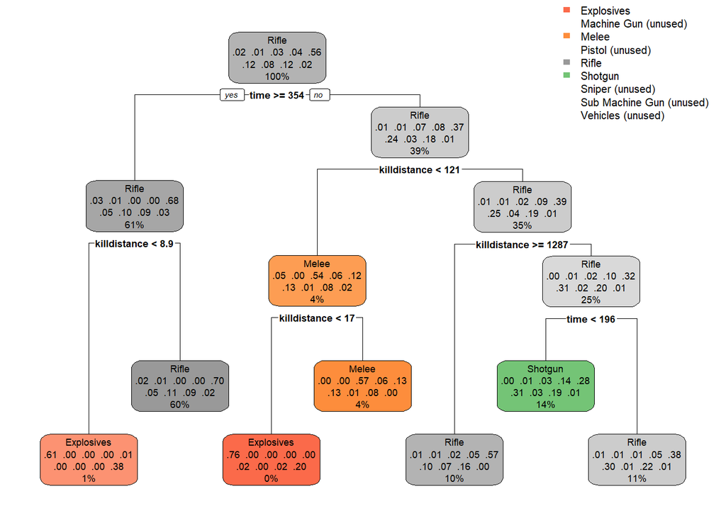

```r
#saveRDS(rparts1, "./rparts1")

rpart.plot(srparts1$finalModel)
```

SVM on scaled data

```r
set.seed(102)
svm1<- svm(GunType~.  - killed_by, data = mysample1_train, scale=TRUE, kernel = "linear", cross = 3)

svm_predict1<-predict(svm1,mysample1_test)
confusionMatrix(svm_predict1,mysample1_test$GunType)
```

```
## Confusion Matrix and Statistics
##
##                  Reference
## Prediction        Explosives Machine Gun Melee Pistol Rifle Shotgun Sniper
##   Explosives               0           0     0      0     0       0      0
##   Machine Gun              0           0     0      0     0       0      0
##   Melee                    0           0     0      0     0       0      0
##   Pistol                   0           0     0      0     0       0      0
##   Rifle                  181          59   225    271  4195     905    570
##   Shotgun                  0           0     0      0     0       0      0
##   Sniper                   0           0     0      0     0       0      0
##   Sub Machine Gun          0           0     0      0     0       0      0
##   Vehicles                 0           0     0      0     0       0      0
##                  Reference
## Prediction        Sub Machine Gun Vehicles
##   Explosives                    0        0
##   Machine Gun                   0        0
##   Melee                         0        0
##   Pistol                        0        0
##   Rifle                       931      161
##   Shotgun                       0        0
##   Sniper                        0        0
##   Sub Machine Gun               0        0
##   Vehicles                      0        0
##
## Overall Statistics
##
##                Accuracy : 0.5595
##                  95% CI : (0.5482, 0.5708)
##     No Information Rate : 0.5595
##     P-Value [Acc > NIR] : 0.5048
##
##                   Kappa : 0
##  Mcnemar's Test P-Value : NA
##
## Statistics by Class:
##
##                      Class: Explosives Class: Machine Gun Class: Melee
## Sensitivity                    0.00000           0.000000      0.00000
## Specificity                    1.00000           1.000000      1.00000
```

[output cut: 9 more lines]

```
## Pos Pred Value                 NaN       0.5595            NaN
## Neg Pred Value             0.96386          NaN         0.8793
## Prevalence                 0.03614       0.5595         0.1207
## Detection Rate             0.00000       0.5595         0.0000
## Detection Prevalence       0.00000       1.0000         0.0000
## Balanced Accuracy          0.50000       0.5000         0.5000
##                      Class: Sniper Class: Sub Machine Gun Class: Vehicles
## Sensitivity                0.00000                 0.0000         0.00000
## Specificity                1.00000                 1.0000         1.00000
## Pos Pred Value                 NaN                    NaN             NaN
## Neg Pred Value             0.92398                 0.8758         0.97853
## Prevalence                 0.07602                 0.1242         0.02147
## Detection Rate             0.00000                 0.0000         0.00000
## Detection Prevalence       0.00000                 0.0000         0.00000
## Balanced Accuracy          0.50000                 0.5000         0.50000
```

```r
saveRDS(svm1, "./svm1.rds")

set.seed(1231)
svm2<- svm(GunType~.  - killed_by, data = mysample2_train, scale=TRUE, kernel = "radial", cross = 3)

svm_predict2<-predict(svm2,mysample2_test)
confusionMatrix(svm_predict2,mysample2_test$GunType)
```

```
## Confusion Matrix and Statistics
##
##                  Reference
## Prediction        Explosives Machine Gun Melee Pistol Rifle Shotgun Sniper
##   Explosives               0           0     0      0     0       0      0
##   Machine Gun              0           0     0      0     0       0      0
##   Melee                    0           0     0      0     0       0      0
##   Pistol                   0           0     0      0     0       0      0
##   Rifle                  178          58   232    271  4172     916    549
##   Shotgun                  0           0     0      0     0       0      0
##   Sniper                   0           0     0      0     0       0      0
##   Sub Machine Gun          0           0     0      0     0       0      0
##   Vehicles                 0           0     0      0     0       0      0
##                  Reference
## Prediction        Sub Machine Gun Vehicles
##   Explosives                    0        0
##   Machine Gun                   0        0
##   Melee                         0        0
##   Pistol                        0        0
##   Rifle                       967      155
##   Shotgun                       0        0
##   Sniper                        0        0
##   Sub Machine Gun               0        0
##   Vehicles                      0        0
##
## Overall Statistics
##
##                Accuracy : 0.5564
##                  95% CI : (0.5451, 0.5677)
##     No Information Rate : 0.5564
##     P-Value [Acc > NIR] : 0.5048
##
##                   Kappa : 0
##  Mcnemar's Test P-Value : NA
##
## Statistics by Class:
##
##                      Class: Explosives Class: Machine Gun Class: Melee
## Sensitivity                    0.00000           0.000000      0.00000
## Specificity                    1.00000           1.000000      1.00000
```

[output cut: 9 more lines]

```
## Pos Pred Value                 NaN       0.5564            NaN
## Neg Pred Value             0.96386          NaN         0.8778
## Prevalence                 0.03614       0.5564         0.1222
## Detection Rate             0.00000       0.5564         0.0000
## Detection Prevalence       0.00000       1.0000         0.0000
## Balanced Accuracy          0.50000       0.5000         0.5000
##                      Class: Sniper Class: Sub Machine Gun Class: Vehicles
## Sensitivity                0.00000                  0.000         0.00000
## Specificity                1.00000                  1.000         1.00000
## Pos Pred Value                 NaN                    NaN             NaN
## Neg Pred Value             0.92678                  0.871         0.97933
## Prevalence                 0.07322                  0.129         0.02067
## Detection Rate             0.00000                  0.000         0.00000
## Detection Prevalence       0.00000                  0.000         0.00000
## Balanced Accuracy          0.50000                  0.500         0.50000
```

```r
saveRDS(svm2, "./svm2.rds")

set.seed(7000)
svm3<- svm(GunType~.  - killed_by, data = mysample3_train, scale=TRUE, kernel = "radial", cross = 3)

svm_predict3<-predict(svm3,mysample3_test)
confusionMatrix(svm_predict3,mysample3_test$GunType)
```

```
## Confusion Matrix and Statistics
##
##                  Reference
## Prediction        Explosives Machine Gun Melee Pistol Rifle Shotgun Sniper
##   Explosives               0           0     0      0     0       0      0
##   Machine Gun              0           0     0      0     0       0      0
##   Melee                    0           0     0      0     0       0      0
##   Pistol                   0           0     0      0     0       0      0
##   Rifle                  172          52   230    273  4187     928    563
##   Shotgun                  0           0     0      0     0       0      0
##   Sniper                   0           0     0      0     0       0      0
##   Sub Machine Gun          0           0     0      0     0       0      0
##   Vehicles                 0           0     0      0     0       0      0
##                  Reference
## Prediction        Sub Machine Gun Vehicles
##   Explosives                    0        0
##   Machine Gun                   0        0
##   Melee                         0        0
##   Pistol                        0        0
##   Rifle                       937      154
##   Shotgun                       0        0
##   Sniper                        0        0
##   Sub Machine Gun               0        0
##   Vehicles                      0        0
##
## Overall Statistics
##
##                Accuracy : 0.5586
##                  95% CI : (0.5472, 0.5698)
##     No Information Rate : 0.5586
##     P-Value [Acc > NIR] : 0.5048
##
##                   Kappa : 0
##  Mcnemar's Test P-Value : NA
##
## Statistics by Class:
##
##                      Class: Explosives Class: Machine Gun Class: Melee
## Sensitivity                    0.00000           0.000000      0.00000
## Specificity                    1.00000           1.000000      1.00000
```

[output cut: 9 more lines]

```
## Pos Pred Value                 NaN       0.5586            NaN
## Neg Pred Value             0.96358          NaN         0.8762
## Prevalence                 0.03642       0.5586         0.1238
## Detection Rate             0.00000       0.5586         0.0000
## Detection Prevalence       0.00000       1.0000         0.0000
## Balanced Accuracy          0.50000       0.5000         0.5000
##                      Class: Sniper Class: Sub Machine Gun Class: Vehicles
## Sensitivity                0.00000                  0.000         0.00000
## Specificity                1.00000                  1.000         1.00000
## Pos Pred Value                 NaN                    NaN             NaN
## Neg Pred Value             0.92489                  0.875         0.97946
## Prevalence                 0.07511                  0.125         0.02054
## Detection Rate             0.00000                  0.000         0.00000
## Detection Prevalence       0.00000                  0.000         0.00000
## Balanced Accuracy          0.50000                  0.500         0.50000
```

```r
saveRDS(svm3, "./svm3.rds")
```